# Travaglio et al., medRxiv 2020 (v04)

```r
# Drop Public Administration because not significant
summary(model_NOx_gamma.final.rsd <- glm(formula = nox_val ~ X.people.per.sq.km + petroleum.Agriculture +
    Manufactured.Solid.Fuels.Domestic + petroleum.Commercial +
    petroleum.Rail, family = Gamma(link = "log"),
    data = fossilfuel_2017.omit))
```

```
##
## Call:
## glm(formula = nox_val ~ X.people.per.sq.km + petroleum.Agriculture +
##     Manufactured.Solid.Fuels.Domestic + petroleum.Commercial +
##     petroleum.Rail, family = Gamma(link = "log"), data = fossilfuel_2017.omit)
##
## Deviance Residuals:
##      Min        1Q    Median        3Q       Max
## -1.53944  -0.25474  -0.03266   0.17177   1.49509
##
## Coefficients:
##                                     Estimate Std. Error t value Pr(>|t|)
## (Intercept)                        2.652e+00  3.735e-02  71.012  < 2e-16 ***
## X.people.per.sq.km                 1.095e-04  7.995e-06  13.700  < 2e-16 ***
## petroleum.Agriculture             -9.140e-02  8.115e-03 -11.263  < 2e-16 ***
## Manufactured.Solid.Fuels.Domestic  1.993e-01  5.976e-02   3.335 0.000962 ***
## petroleum.Commercial               2.522e-01  9.351e-02   2.697 0.007390 **
## petroleum.Rail                     1.932e-02  1.094e-02   1.766 0.078511 .
## ---
## Signif. codes:  0 '***' 0.001 '**' 0.01 '*' 0.05 '.' 0.1 ' ' 1
##
## (Dispersion parameter for Gamma family taken to be 0.1143779)
##
##     Null deviance: 94.264  on 299  degrees of freedom
## Residual deviance: 33.089  on 294  degrees of freedom
## AIC: 1891.7
##
## Number of Fisher Scoring iterations: 8
```

```r
# Drop Petroleum Rail because not significant
summary(model_NOx_gamma.final.rsd3 <- glm(formula = nox_val ~ X.people.per.sq.km + petroleum.Agriculture +
    Manufactured.Solid.Fuels.Domestic + petroleum.Commercial, family = Gamma(link = "log"),
    data = fossilfuel_2017.omit))
```

```
##
## Call:
## glm(formula = nox_val ~ X.people.per.sq.km + petroleum.Agriculture +
##     Manufactured.Solid.Fuels.Domestic + petroleum.Commercial,
##     family = Gamma(link = "log"), data = fossilfuel_2017.omit)
##
## Deviance Residuals:
##      Min        1Q    Median        3Q       Max
## -1.52518  -0.26620  -0.03299   0.17772   1.46828
##
## Coefficients:
##                                     Estimate Std. Error t value Pr(>|t|)
## (Intercept)                        2.658e+00  3.711e-02  71.628  < 2e-16 ***
## X.people.per.sq.km                 1.086e-04  7.970e-06  13.623  < 2e-16 ***
## petroleum.Agriculture             -9.033e-02  8.114e-03 -11.133  < 2e-16 ***
## Manufactured.Solid.Fuels.Domestic  2.361e-01  5.621e-02   4.201 3.52e-05 ***
## petroleum.Commercial               2.701e-01  9.292e-02   2.907  0.00393 **
## ---
## Signif. codes:  0 '***' 0.001 '**' 0.01 '*' 0.05 '.' 0.1 ' ' 1
##
## (Dispersion parameter for Gamma family taken to be 0.1144435)
##
##     Null deviance: 94.264  on 299  degrees of freedom
## Residual deviance: 33.458  on 295  degrees of freedom
## AIC: 1893.1
##
## Number of Fisher Scoring iterations: 8
```

```r
#Check for collinearity
vif(model_NOx_gamma.final.rsd3) # VIF <5
```

```
##                X.people.per.sq.km             petroleum.Agriculture
##                          1.197093                          2.752645
## Manufactured.Solid.Fuels.Domestic              petroleum.Commercial
##                          2.290569                          1.884869
```

Last, we will look at the effect of domestic and non-domestic gas consumption:

```r
summary(model_NOx_gamma.gas <- glm(data = fossilfuel_2017.omit, nox_val ~  X.people.per.sq.km + Domestic.mean.gas.consumption + Non.domestic.mean.gas.consumption, family  = Gamma(link = "log")))
```

```
##
## Call:
## glm(formula = nox_val ~ X.people.per.sq.km + Domestic.mean.gas.consumption +
##     Non.domestic.mean.gas.consumption, family = Gamma(link = "log"),
##     data = fossilfuel_2017.omit)
##
## Deviance Residuals:
##      Min        1Q    Median        3Q       Max
## -1.65609  -0.30099  -0.02535   0.21248   1.80623
##
## Coefficients:
##                                     Estimate Std. Error t value Pr(>|t|)
## (Intercept)                        2.216e+00  2.346e-01   9.447   <2e-16 ***
## X.people.per.sq.km                 1.468e-04  9.287e-06  15.806   <2e-16 ***
## Domestic.mean.gas.consumption      3.194e-05  1.637e-05   1.951    0.052 .
## Non.domestic.mean.gas.consumption -3.762e-08  4.239e-08  -0.888    0.376
## ---
## Signif. codes:  0 '***' 0.001 '**' 0.01 '*' 0.05 '.' 0.1 ' ' 1
##
## (Dispersion parameter for Gamma family taken to be 0.1643036)
##
##     Null deviance: 94.264  on 299  degrees of freedom
## Residual deviance: 48.733  on 296  degrees of freedom
## AIC: 2006.5
##
## Number of Fisher Scoring iterations: 7
```

```r
# Non domestic gas consumption is not significant so will be dropped
summary(model_NOx_gamma.gas.v2 <- glm(data = fossilfuel_2017.omit, nox_val ~  X.people.per.sq.km + Domestic.mean.gas.consumption, family  = Gamma(link = "log")))
```

```
##
## Call:
## glm(formula = nox_val ~ X.people.per.sq.km + Domestic.mean.gas.consumption,
##     family = Gamma(link = "log"), data = fossilfuel_2017.omit)
##
## Deviance Residuals:
##      Min        1Q    Median        3Q       Max
## -1.66099  -0.31106  -0.02799   0.21552   1.80287
##
## Coefficients:
##                                Estimate Std. Error t value Pr(>|t|)
## (Intercept)                   2.138e+00  2.192e-01   9.751   <2e-16 ***
## X.people.per.sq.km            1.488e-04  9.057e-06  16.428   <2e-16 ***
## Domestic.mean.gas.consumption 3.556e-05  1.594e-05   2.231   0.0264 *
## ---
## Signif. codes:  0 '***' 0.001 '**' 0.01 '*' 0.05 '.' 0.1 ' ' 1
##
## (Dispersion parameter for Gamma family taken to be 0.1643312)
##
##     Null deviance: 94.264  on 299  degrees of freedom
## Residual deviance: 48.855  on 297  degrees of freedom
## AIC: 2005.3
##
## Number of Fisher Scoring iterations: 7
```

```r
vif(model_NOx_gamma.gas.v2) # no collinearity
```

```
##            X.people.per.sq.km Domestic.mean.gas.consumption
##                       1.07663                       1.07663
```

```r
#plot(model_NOx_gamma.gas.v2) # no significant outlier
```

Based on the results above, it can be concluded that domestic gas consumption exerts a significant effect on NOx levels in England.  
#### O3

Same as above: analyse the data distribution of the target or response variable (O3 concentration). To do this, we will use the following functions:

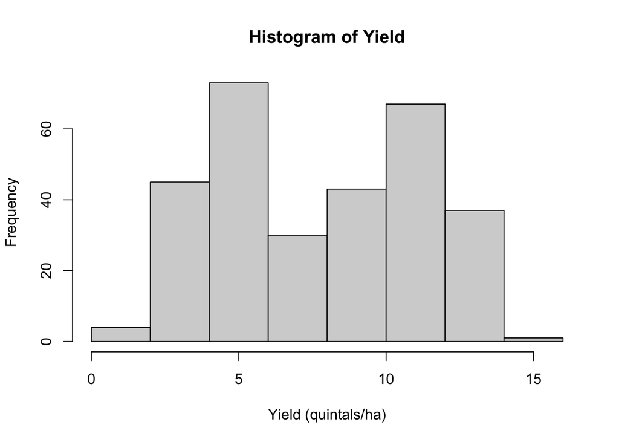

```r
hist(fossilfuel_2017.omit$o3_val, main="Histogram of Yield", xlab="Yield (quintals/ha)")
```

```r
#qqnorm(fossilfuel_2017.omit$o3_val, main="QQplot of O3")
# Visualise refernce line
library("car")
#qqPlot(fossilfuel_2017.omit$o3_val,  main="QQplot of NO2")
skewness(fossilfuel_2017.omit$o3_val)
```

```
## [1] 0.01756001
```

Unlike data for NO2 and NOx, because the dv values of O3 values is overdispersed and slightly skewed, we have two options: gamma glm model or simply gaussian glm for O3 data. Our data does not appear significantly skewed so applying a gaussian model could be more appropriate. We will compare relative AIC values to choose the best model.

```r
# Gamma
summary(model_O3_gamma.vif2 <- glm(data = fossilfuel_2017.omit, o3_val ~ X.people.per.sq.km + personal.buses.A.roads + personal.motorcycles.Motorways + personal.motorcycles.A.roads + personal.motorcycles.Minor.roads + freight.HGV.Motorways + freight.HGV.A.roads, family  = Gamma(link = "log")))
```

```
##
## Call:
## glm(formula = o3_val ~ X.people.per.sq.km + personal.buses.A.roads +
##     personal.motorcycles.Motorways + personal.motorcycles.A.roads +
##     personal.motorcycles.Minor.roads + freight.HGV.Motorways +
##     freight.HGV.A.roads, family = Gamma(link = "log"), data = fossilfuel_2017.omit)
##
## Deviance Residuals:
##      Min        1Q    Median        3Q       Max
## -2.45610  -0.33991  -0.01237   0.23605   1.05964
##
## Coefficients:
##                                    Estimate Std. Error t value Pr(>|t|)
## (Intercept)                       1.978e+00  4.669e-02  42.356  < 2e-16 ***
## X.people.per.sq.km                1.210e-06  1.293e-05   0.094    0.926
## personal.buses.A.roads           -3.870e-04  3.297e-05 -11.737  < 2e-16 ***
## personal.motorcycles.Motorways    2.260e-03  4.270e-04   5.292 2.38e-07 ***
## personal.motorcycles.A.roads      1.121e-03  2.026e-04   5.533 6.99e-08 ***
## personal.motorcycles.Minor.roads  1.392e-03  2.225e-04   6.255 1.41e-09 ***
## freight.HGV.Motorways            -1.612e-05  2.501e-06  -6.445 4.77e-10 ***
## freight.HGV.A.roads              -7.568e-07  3.680e-06  -0.206    0.837
## ---
## Signif. codes:  0 '***' 0.001 '**' 0.01 '*' 0.05 '.' 0.1 ' ' 1
##
## (Dispersion parameter for Gamma family taken to be 0.1386831)
##
##     Null deviance: 79.082  on 299  degrees of freedom
## Residual deviance: 47.822  on 292  degrees of freedom
## AIC: 1476.8
##
## Number of Fisher Scoring iterations: 7
```

```r
# Gaussian glm
summary(model_O3_gaussian.vif <- glm(data = fossilfuel_2017.omit, o3_val ~ X.people.per.sq.km + personal.buses.A.roads + personal.motorcycles.Motorways + personal.motorcycles.A.roads + personal.motorcycles.Minor.roads + freight.HGV.Motorways + freight.HGV.A.roads, family = "gaussian"))
```

```
##
## Call:
## glm(formula = o3_val ~ X.people.per.sq.km + personal.buses.A.roads +
##     personal.motorcycles.Motorways + personal.motorcycles.A.roads +
##     personal.motorcycles.Minor.roads + freight.HGV.Motorways +
##     freight.HGV.A.roads, family = "gaussian", data = fossilfuel_2017.omit)
##
## Deviance Residuals:
##     Min       1Q   Median       3Q      Max
## -8.2330  -2.2562  -0.1874   2.0642   7.9001
##
## Coefficients:
##                                    Estimate Std. Error t value Pr(>|t|)
## (Intercept)                       7.451e+00  3.363e-01  22.157  < 2e-16 ***
## X.people.per.sq.km               -1.439e-04  9.315e-05  -1.545    0.123
## personal.buses.A.roads           -2.251e-03  2.375e-04  -9.478  < 2e-16 ***
## personal.motorcycles.Motorways    1.697e-02  3.076e-03   5.518 7.58e-08 ***
## personal.motorcycles.A.roads      9.844e-03  1.459e-03   6.745 8.20e-11 ***
## personal.motorcycles.Minor.roads  8.073e-03  1.603e-03   5.037 8.31e-07 ***
## freight.HGV.Motorways            -1.168e-04  1.802e-05  -6.482 3.85e-10 ***
## freight.HGV.A.roads              -3.214e-05  2.651e-05  -1.213    0.226
## ---
## Signif. codes:  0 '***' 0.001 '**' 0.01 '*' 0.05 '.' 0.1 ' ' 1
##
## (Dispersion parameter for gaussian family taken to be 7.194641)
##
##     Null deviance: 3556.1  on 299  degrees of freedom
## Residual deviance: 2100.8  on 292  degrees of freedom
## AIC: 1453.3
##
## Number of Fisher Scoring iterations: 2
```

Above analysis suggests that a gaussian model (AIC 1453) performs better than a gamma with log link (AIC 1476) based on goodness of fit. Nonetheless we need to check that our model meets all assumptions for linear regression:

```r
# check residuals
#plot(model_O3_gaussian.vif)
```

We will proceed with stepwise regression on VIF-corrected variables:

```r
### Define full and null models and do step procedure
model_O3.0_gamma <- glm(o3_val ~ 1, data = fossilfuel_2017.omit, family = "gaussian")
step(model_O3.0_gamma, direction = "both", scope = formula(model_O3_gaussian.vif, test = "Chisq"))
```

```
## Start:  AIC=1597.15
## o3_val ~ 1
##
##                                    Df Deviance    AIC
## + personal.buses.A.roads            1   3175.6 1565.2
## + X.people.per.sq.km                1   3378.9 1583.8
## + personal.motorcycles.Motorways    1   3490.8 1593.6
## + freight.HGV.Motorways             1   3491.2 1593.6
## <none>                                  3556.1 1597.2
## + freight.HGV.A.roads               1   3551.3 1598.8
## + personal.motorcycles.A.roads      1   3551.6 1598.8
## + personal.motorcycles.Minor.roads  1   3554.2 1599.0
##
## Step:  AIC=1565.2
## o3_val ~ personal.buses.A.roads
##
##                                    Df Deviance    AIC
## + personal.motorcycles.A.roads      1   2688.4 1517.2
## + personal.motorcycles.Minor.roads  1   2913.3 1541.3
## + freight.HGV.Motorways             1   3109.8 1560.9
## + personal.motorcycles.Motorways    1   3121.0 1562.0
## <none>                                  3175.6 1565.2
## + freight.HGV.A.roads               1   3155.5 1565.3
## + X.people.per.sq.km                1   3175.2 1567.2
## - personal.buses.A.roads            1   3556.1 1597.2
##
## Step:  AIC=1517.24
## o3_val ~ personal.buses.A.roads + personal.motorcycles.A.roads
##
##                                    Df Deviance    AIC
## + personal.motorcycles.Minor.roads  1   2474.5 1494.4
## + personal.motorcycles.Motorways    1   2642.6 1514.1
## + freight.HGV.Motorways             1   2643.7 1514.2
## <none>                                  2688.4 1517.2
## + X.people.per.sq.km                1   2672.3 1517.4
## + freight.HGV.A.roads               1   2681.8 1518.5
## - personal.motorcycles.A.roads      1   3175.6 1565.2
## - personal.buses.A.roads            1   3551.6 1598.8
##
## Step:  AIC=1494.37
```

[output cut: 26 more lines]

```
##
## Step:  AIC=1452.09
## o3_val ~ personal.buses.A.roads + personal.motorcycles.A.roads +
##     personal.motorcycles.Minor.roads + freight.HGV.Motorways +
##     personal.motorcycles.Motorways
##
##                                    Df Deviance    AIC
## <none>                                  2120.8 1452.1
## + X.people.per.sq.km                1   2111.4 1452.8
## + freight.HGV.A.roads               1   2118.0 1453.7
## - personal.motorcycles.Minor.roads  1   2327.8 1478.0
## - personal.motorcycles.Motorways    1   2380.2 1484.7
## - personal.motorcycles.A.roads      1   2454.7 1494.0
## - freight.HGV.Motorways             1   2460.8 1494.7
## - personal.buses.A.roads            1   3036.3 1557.7
```

```
##
## Call:  glm(formula = o3_val ~ personal.buses.A.roads + personal.motorcycles.A.roads +
##     personal.motorcycles.Minor.roads + freight.HGV.Motorways +
##     personal.motorcycles.Motorways, family = "gaussian", data = fossilfuel_2017.omit)
##
## Coefficients:
##                      (Intercept)            personal.buses.A.roads
##                        7.2051799                        -0.0023398
##     personal.motorcycles.A.roads  personal.motorcycles.Minor.roads
##                        0.0088348                         0.0081175
##            freight.HGV.Motorways    personal.motorcycles.Motorways
##                       -0.0001175                         0.0178090
##
## Degrees of Freedom: 299 Total (i.e. Null);  294 Residual
## Null Deviance:       3556
## Residual Deviance: 2121  AIC: 1452
```

Based on the results of the stepwise regression and VIF test, we proceed to build our final model:

```r
### Define final model based on stepwise regression results
summary(model_O3_gamma_final <-glm(formula = o3_val ~ personal.buses.A.roads + personal.motorcycles.A.roads +
    personal.motorcycles.Minor.roads + freight.HGV.Motorways +
    personal.motorcycles.Motorways, family = "gaussian", data = fossilfuel_2017.omit))
```

```
##
## Call:
## glm(formula = o3_val ~ personal.buses.A.roads + personal.motorcycles.A.roads +
##     personal.motorcycles.Minor.roads + freight.HGV.Motorways +
##     personal.motorcycles.Motorways, family = "gaussian", data = fossilfuel_2017.omit)
##
## Deviance Residuals:
##     Min       1Q   Median       3Q      Max
## -7.8405  -2.2501  -0.1434   2.2126   7.4716
##
## Coefficients:
##                                    Estimate Std. Error t value Pr(>|t|)
## (Intercept)                       7.205e+00  3.017e-01  23.886  < 2e-16 ***
## personal.buses.A.roads           -2.340e-03  2.077e-04 -11.265  < 2e-16 ***
## personal.motorcycles.A.roads      8.835e-03  1.299e-03   6.803 5.73e-11 ***
## personal.motorcycles.Minor.roads  8.117e-03  1.515e-03   5.358 1.71e-07 ***
## freight.HGV.Motorways            -1.175e-04  1.712e-05  -6.866 3.93e-11 ***
## personal.motorcycles.Motorways    1.781e-02  2.970e-03   5.996 5.91e-09 ***
## ---
## Signif. codes:  0 '***' 0.001 '**' 0.01 '*' 0.05 '.' 0.1 ' ' 1
##
## (Dispersion parameter for gaussian family taken to be 7.213572)
##
##     Null deviance: 3556.1  on 299  degrees of freedom
## Residual deviance: 2120.8  on 294  degrees of freedom
## AIC: 1452.1
##
## Number of Fisher Scoring iterations: 2
```

```r
vif(model_O3_gamma_final) # VIF <5
```

```
##           personal.buses.A.roads     personal.motorcycles.A.roads
##                         3.500653                         2.779741
## personal.motorcycles.Minor.roads            freight.HGV.Motorways
##                         1.961206                         2.293140
##   personal.motorcycles.Motorways
##                         2.309594
```

```r
#plot(model_O3_gamma_final)
```

Construction and industrial sites:

```r
summary(model_O3_gamma.rsd.vif <- glm(data = fossilfuel_2017.omit, o3_val ~ X.people.per.sq.km + petroleum.Industrial + petroleum.Rail + petroleum.Public.Administration + petroleum.Commercial + petroleum.Agriculture + Manufactured.Solid.Fuels.Domestic + bioenergy, family = "gaussian"))
```

```
##
## Call:
## glm(formula = o3_val ~ X.people.per.sq.km + petroleum.Industrial +
##     petroleum.Rail + petroleum.Public.Administration + petroleum.Commercial +
##     petroleum.Agriculture + Manufactured.Solid.Fuels.Domestic +
##     bioenergy, family = "gaussian", data = fossilfuel_2017.omit)
##
## Deviance Residuals:
##     Min       1Q   Median       3Q      Max
## -8.7224  -2.8783   0.0898   2.7742   8.3195
##
## Coefficients:
##                                     Estimate Std. Error t value Pr(>|t|)
## (Intercept)                        8.468e+00  3.679e-01  23.018  < 2e-16 ***
## X.people.per.sq.km                -3.145e-04  7.813e-05  -4.025 7.27e-05 ***
## petroleum.Industrial              -1.241e-03  2.540e-03  -0.489   0.6255
## petroleum.Rail                    -3.088e-01  1.089e-01  -2.835   0.0049 **
## petroleum.Public.Administration    1.174e+00  7.202e-01   1.630   0.1041
## petroleum.Commercial               1.664e+00  9.246e-01   1.799   0.0730 .
## petroleum.Agriculture              7.358e-02  7.962e-02   0.924   0.3562
## Manufactured.Solid.Fuels.Domestic -1.465e-01  5.896e-01  -0.248   0.8040
## bioenergy                         -2.294e-02  1.189e-02  -1.929   0.0547 .
## ---
## Signif. codes:  0 '***' 0.001 '**' 0.01 '*' 0.05 '.' 0.1 ' ' 1
##
## (Dispersion parameter for gaussian family taken to be 10.88305)
##
##     Null deviance: 3556.1  on 299  degrees of freedom
## Residual deviance: 3167.0  on 291  degrees of freedom
## AIC: 1578.4
##
## Number of Fisher Scoring iterations: 2
```

```r
vif(model_O3_gamma.rsd.vif) # no collinearity
```

```
##                X.people.per.sq.km              petroleum.Industrial
##                          1.209843                          1.040351
##                    petroleum.Rail   petroleum.Public.Administration
##                          1.580011                          1.104873
##              petroleum.Commercial             petroleum.Agriculture
##                          1.962510                          2.787182
## Manufactured.Solid.Fuels.Domestic                         bioenergy
##                          2.650664                          1.096700
```

We will proceed to run a stepwise regression to drop unused variables:

```r
model_O3.0_gamma <- glm(o3_val ~ 1, data = fossilfuel_2017.omit, family = "gaussian")
step(model_O3.0_gamma, direction = "both", scope = formula(model_O3_gamma.rsd.vif, test = "Chisq"))
```

```
## Start:  AIC=1597.15
## o3_val ~ 1
##
##                                     Df Deviance    AIC
## + X.people.per.sq.km                 1   3378.9 1583.8
## + petroleum.Agriculture              1   3492.3 1593.7
## + petroleum.Commercial               1   3505.1 1594.8
## + petroleum.Public.Administration    1   3528.6 1596.8
## <none>                                   3556.1 1597.2
## + bioenergy                          1   3534.0 1597.3
## + Manufactured.Solid.Fuels.Domestic  1   3543.5 1598.1
## + petroleum.Rail                     1   3546.4 1598.3
## + petroleum.Industrial               1   3554.6 1599.0
##
## Step:  AIC=1583.82
## o3_val ~ X.people.per.sq.km
##
##                                     Df Deviance    AIC
## + petroleum.Commercial               1   3339.6 1582.3
## + bioenergy                          1   3340.2 1582.4
## + petroleum.Rail                     1   3341.8 1582.5
## + petroleum.Public.Administration    1   3355.1 1583.7
## <none>                                   3378.9 1583.8
## + petroleum.Agriculture              1   3366.0 1584.7
## + petroleum.Industrial               1   3372.7 1585.3
## + Manufactured.Solid.Fuels.Domestic  1   3378.9 1585.8
## - X.people.per.sq.km                 1   3556.1 1597.2
##
## Step:  AIC=1582.31
## o3_val ~ X.people.per.sq.km + petroleum.Commercial
##
##                                     Df Deviance    AIC
## + petroleum.Rail                     1   3247.7 1575.9
## + bioenergy                          1   3290.9 1579.9
## <none>                                   3339.6 1582.3
## + Manufactured.Solid.Fuels.Domestic  1   3318.2 1582.4
## + petroleum.Public.Administration    1   3327.4 1583.2
## + petroleum.Industrial               1   3329.2 1583.4
## - petroleum.Commercial               1   3378.9 1583.8
## + petroleum.Agriculture              1   3339.1 1584.3
```

[output cut: 30 more lines]

```
##
## Step:  AIC=1573.57
## o3_val ~ X.people.per.sq.km + petroleum.Commercial + petroleum.Rail +
##     bioenergy + petroleum.Public.Administration
##
##                                     Df Deviance    AIC
## <none>                                   3179.5 1573.6
## - petroleum.Public.Administration    1   3208.1 1574.2
## + petroleum.Agriculture              1   3170.3 1574.7
## - bioenergy                          1   3218.3 1575.2
## + petroleum.Industrial               1   3176.7 1575.3
## + Manufactured.Solid.Fuels.Domestic  1   3179.1 1575.5
## - petroleum.Commercial               1   3265.4 1579.6
## - petroleum.Rail                     1   3278.7 1580.8
## - X.people.per.sq.km                 1   3410.3 1592.6
```

```
##
## Call:  glm(formula = o3_val ~ X.people.per.sq.km + petroleum.Commercial +
##     petroleum.Rail + bioenergy + petroleum.Public.Administration,
##     family = "gaussian", data = fossilfuel_2017.omit)
##
## Coefficients:
##                     (Intercept)               X.people.per.sq.km
##                       8.4374741                       -0.0003364
##            petroleum.Commercial                   petroleum.Rail
##                       2.0726020                       -0.3011018
##                       bioenergy  petroleum.Public.Administration
##                      -0.0217660                        1.1645811
##
## Degrees of Freedom: 299 Total (i.e. Null);  294 Residual
## Null Deviance:       3556
## Residual Deviance: 3179  AIC: 1574
```

Final model for residual fuels:

```r
### Define final model based on stepwise regression results
summary(model_O3_gamma_final.rsd <-glm(formula = o3_val ~ X.people.per.sq.km + petroleum.Commercial +
    petroleum.Rail,
    family = "gaussian", data = fossilfuel_2017.omit))
```

```
##
## Call:
## glm(formula = o3_val ~ X.people.per.sq.km + petroleum.Commercial +
##     petroleum.Rail, family = "gaussian", data = fossilfuel_2017.omit)
##
## Deviance Residuals:
##     Min       1Q   Median       3Q      Max
## -9.3487  -2.9115  -0.0239   2.8478   8.3086
##
## Coefficients:
##                        Estimate Std. Error t value Pr(>|t|)
## (Intercept)           8.285e+00  3.195e-01  25.928  < 2e-16 ***
## X.people.per.sq.km   -3.210e-04  7.304e-05  -4.395 1.54e-05 ***
## petroleum.Commercial  2.140e+00  7.310e-01   2.928  0.00367 **
## petroleum.Rail       -2.836e-01  9.802e-02  -2.894  0.00409 **
## ---
## Signif. codes:  0 '***' 0.001 '**' 0.01 '*' 0.05 '.' 0.1 ' ' 1
##
## (Dispersion parameter for gaussian family taken to be 10.97208)
##
##     Null deviance: 3556.1  on 299  degrees of freedom
## Residual deviance: 3247.7  on 296  degrees of freedom
## AIC: 1575.9
##
## Number of Fisher Scoring iterations: 2
```

```r
## Dropped bioenergy and Petroleum Admin - ns
vif(model_O3_gamma_final.rsd)
```

```
##   X.people.per.sq.km petroleum.Commercial       petroleum.Rail
##             1.048588             1.216676             1.269279
```

```r
#plot(model_O3_gamma_final.rsd)
```

Our results suggest that petroleum consumed from rail transport and commercial activities is significantly associated with O3 AQ levels in England.

Last, we will look at the effect of domestic and non-domestic gas consumption:

```r
summary(model_O3_gamma.gas <- glm(data = fossilfuel_2017.omit, o3_val ~  X.people.per.sq.km + Domestic.mean.gas.consumption + Non.domestic.mean.gas.consumption, family  = "gaussian"))
```

```
##
## Call:
## glm(formula = o3_val ~ X.people.per.sq.km + Domestic.mean.gas.consumption +
##     Non.domestic.mean.gas.consumption, family = "gaussian", data = fossilfuel_2017.omit)
##
## Deviance Residuals:
##     Min       1Q   Median       3Q      Max
## -7.1558  -3.0658   0.5701   2.7090   9.4516
##
## Coefficients:
##                                     Estimate Std. Error t value Pr(>|t|)
## (Intercept)                        1.066e+01  1.899e+00   5.615 4.54e-08 ***
## X.people.per.sq.km                -3.514e-04  7.519e-05  -4.673 4.51e-06 ***
## Domestic.mean.gas.consumption     -9.308e-05  1.325e-04  -0.702    0.483
## Non.domestic.mean.gas.consumption -1.443e-06  3.432e-07  -4.204 3.47e-05 ***
## ---
## Signif. codes:  0 '***' 0.001 '**' 0.01 '*' 0.05 '.' 0.1 ' ' 1
##
## (Dispersion parameter for gaussian family taken to be 10.76952)
##
##     Null deviance: 3556.1  on 299  degrees of freedom
## Residual deviance: 3187.8  on 296  degrees of freedom
## AIC: 1570.4
##
## Number of Fisher Scoring iterations: 2
```

```r
# Domestic gas consumption is not significant so will be dropped
summary(model_O3_gamma.gas.v2 <- glm(data = fossilfuel_2017.omit, o3_val ~  X.people.per.sq.km + Non.domestic.mean.gas.consumption, family  = "gaussian"))
```

```
##
## Call:
## glm(formula = o3_val ~ X.people.per.sq.km + Non.domestic.mean.gas.consumption,
##     family = "gaussian", data = fossilfuel_2017.omit)
##
## Deviance Residuals:
##    Min      1Q  Median      3Q     Max
## -7.007  -3.008   0.586   2.644   9.612
##
## Coefficients:
##                                     Estimate Std. Error t value Pr(>|t|)
## (Intercept)                        9.352e+00  3.439e-01  27.192  < 2e-16 ***
## X.people.per.sq.km                -3.353e-04  7.157e-05  -4.685 4.26e-06 ***
## Non.domestic.mean.gas.consumption -1.388e-06  3.338e-07  -4.157 4.22e-05 ***
## ---
## Signif. codes:  0 '***' 0.001 '**' 0.01 '*' 0.05 '.' 0.1 ' ' 1
##
## (Dispersion parameter for gaussian family taken to be 10.75115)
##
##     Null deviance: 3556.1  on 299  degrees of freedom
## Residual deviance: 3193.1  on 297  degrees of freedom
## AIC: 1568.9
##
## Number of Fisher Scoring iterations: 2
```

```r
vif(model_O3_gamma.gas.v2) # no collinearity
```

```
##                X.people.per.sq.km Non.domestic.mean.gas.consumption
##                          1.027561                          1.027561
```

```r
#plot(model_O3_gamma.gas.v2) # no significant outlier
```

#### SO2

Same as above: analyse the data distribution of the target or response variable (SO2 concentration). To do this, we will use the following functions:

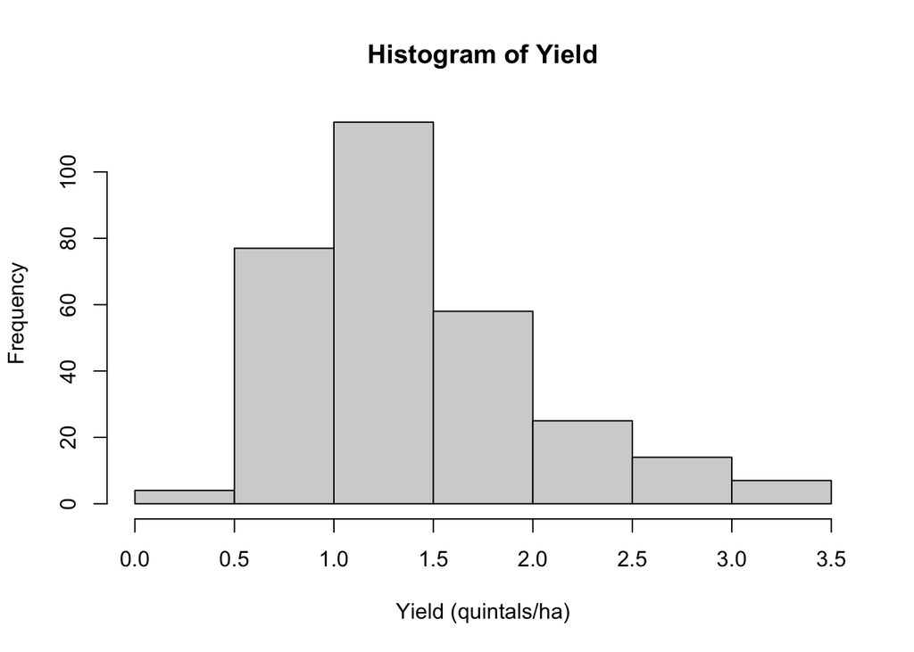

```r
hist(fossilfuel_2017.omit$so2_val, main="Histogram of Yield", xlab="Yield (quintals/ha)")
```

```r
#qqnorm(fossilfuel_2017.omit$so2_val, main="QQplot of SO2")
skewness(fossilfuel_2017.omit$so2_val)
```

```
## [1] 1.035942
```

Data is non-parametric and gamma distributed. Based on the results of VIF correction we call the following model:

```r
summary(model_SO2_gamma.vif <- glm(data = fossilfuel_2017.omit, so2_val ~ X.people.per.sq.km + personal.buses.A.roads + personal.motorcycles.Motorways + personal.motorcycles.A.roads + personal.motorcycles.Minor.roads + freight.HGV.Motorways + freight.HGV.A.roads, family  = Gamma(link = "log")))
```

```
##
## Call:
## glm(formula = so2_val ~ X.people.per.sq.km + personal.buses.A.roads +
##     personal.motorcycles.Motorways + personal.motorcycles.A.roads +
##     personal.motorcycles.Minor.roads + freight.HGV.Motorways +
##     freight.HGV.A.roads, family = Gamma(link = "log"), data = fossilfuel_2017.omit)
##
## Deviance Residuals:
##      Min        1Q    Median        3Q       Max
## -1.19260  -0.24930  -0.05693   0.14666   1.03844
##
## Coefficients:
##                                    Estimate Std. Error t value Pr(>|t|)
## (Intercept)                       2.220e-01  4.358e-02   5.093 6.32e-07 ***
## X.people.per.sq.km                7.621e-05  1.207e-05   6.314 1.01e-09 ***
## personal.buses.A.roads            1.173e-04  3.078e-05   3.811 0.000169 ***
## personal.motorcycles.Motorways   -3.598e-04  3.986e-04  -0.903 0.367414
## personal.motorcycles.A.roads     -1.079e-03  1.891e-04  -5.706 2.84e-08 ***
## personal.motorcycles.Minor.roads  4.953e-05  2.077e-04   0.238 0.811664
## freight.HGV.Motorways             6.387e-06  2.335e-06   2.736 0.006607 **
## freight.HGV.A.roads              -1.045e-06  3.435e-06  -0.304 0.761245
## ---
## Signif. codes:  0 '***' 0.001 '**' 0.01 '*' 0.05 '.' 0.1 ' ' 1
##
## (Dispersion parameter for Gamma family taken to be 0.1208095)
##
##     Null deviance: 49.192  on 299  degrees of freedom
## Residual deviance: 33.464  on 292  degrees of freedom
## AIC: 376.41
##
## Number of Fisher Scoring iterations: 6
```

```r
vif(model_SO2_gamma.vif) # VIF <5
```

```
##               X.people.per.sq.km           personal.buses.A.roads
##                         2.601107                         4.589445
##   personal.motorcycles.Motorways     personal.motorcycles.A.roads
##                         2.483397                         3.520010
## personal.motorcycles.Minor.roads            freight.HGV.Motorways
##                         2.200378                         2.546692
##              freight.HGV.A.roads
##                         1.654252
```

Stepwise regression:

```r
### Define full and null models and do step procedure
model_SO2.0_glm.gamma <- glm(so2_val ~ 1, data = fossilfuel_2017.omit, family = Gamma(link = "log"))
step(model_SO2.0_glm.gamma, direction = "both", scope = formula(model_SO2_gamma.vif, test = "Chisq"))
```

```
## Start:  AIC=480.61
## so2_val ~ 1
##
##                                    Df Deviance    AIC
## + X.people.per.sq.km                1   40.711 433.96
## + personal.buses.A.roads            1   43.295 448.78
## + personal.motorcycles.Minor.roads  1   47.199 471.18
## + freight.HGV.A.roads               1   47.565 473.27
## + personal.motorcycles.A.roads      1   48.659 479.55
## <none>                                  49.192 480.61
## + freight.HGV.Motorways             1   48.991 481.45
## + personal.motorcycles.Motorways    1   49.187 482.58
##
## Step:  AIC=424.43
## so2_val ~ X.people.per.sq.km
##
##                                    Df Deviance    AIC
## + personal.motorcycles.A.roads      1   38.694 412.67
## + freight.HGV.Motorways             1   39.069 415.23
## + personal.buses.A.roads            1   40.307 423.67
## + freight.HGV.A.roads               1   40.375 424.14
## + personal.motorcycles.Motorways    1   40.416 424.42
## <none>                                  40.711 424.43
## + personal.motorcycles.Minor.roads  1   40.482 424.86
## - X.people.per.sq.km                1   49.192 480.24
##
## Step:  AIC=410.84
## so2_val ~ X.people.per.sq.km + personal.motorcycles.A.roads
##
##                                    Df Deviance    AIC
## + personal.buses.A.roads            1   34.729 384.43
## + freight.HGV.Motorways             1   36.460 396.84
## + personal.motorcycles.Minor.roads  1   37.169 401.92
## + personal.motorcycles.Motorways    1   38.162 409.03
## <none>                                  38.694 410.84
## + freight.HGV.A.roads               1   38.672 412.69
## - personal.motorcycles.A.roads      1   40.711 423.31
## - X.people.per.sq.km                1   48.659 480.26
##
## Step:  AIC=379.76
```

[output cut: 11 more lines]

```
## - personal.motorcycles.A.roads      1   40.307 422.23
##
## Step:  AIC=371.31
## so2_val ~ X.people.per.sq.km + personal.motorcycles.A.roads +
##     personal.buses.A.roads + freight.HGV.Motorways
##
##                                    Df Deviance    AIC
## <none>                                  33.562 371.31
## + personal.motorcycles.Motorways    1   33.478 372.61
## + personal.motorcycles.Minor.roads  1   33.561 373.30
## + freight.HGV.A.roads               1   33.562 373.30
## - freight.HGV.Motorways             1   34.729 379.01
## - personal.buses.A.roads            1   36.460 393.39
## - personal.motorcycles.A.roads      1   38.978 414.31
## - X.people.per.sq.km                1   39.193 416.10
```

```
##
## Call:  glm(formula = so2_val ~ X.people.per.sq.km + personal.motorcycles.A.roads +
##     personal.buses.A.roads + freight.HGV.Motorways, family = Gamma(link = "log"),
##     data = fossilfuel_2017.omit)
##
## Coefficients:
##                  (Intercept)            X.people.per.sq.km
##                    2.167e-01                     7.687e-05
## personal.motorcycles.A.roads        personal.buses.A.roads
##                   -1.116e-03                     1.242e-04
##        freight.HGV.Motorways
##                    4.858e-06
##
## Degrees of Freedom: 299 Total (i.e. Null);  295 Residual
## Null Deviance:       49.19
## Residual Deviance: 33.56     AIC: 371.3
```

Based on the results of the stepwise regression, we proceed to build our final model:

```r
### Define final model based on stepwise regression results
summary(model_SO2_gamma_final <-glm(formula = so2_val ~ X.people.per.sq.km + personal.motorcycles.A.roads +
    personal.buses.A.roads + freight.HGV.Motorways, family = Gamma(link = "log"),
    data = fossilfuel_2017.omit))
```

```
##
## Call:
## glm(formula = so2_val ~ X.people.per.sq.km + personal.motorcycles.A.roads +
##     personal.buses.A.roads + freight.HGV.Motorways, family = Gamma(link = "log"),
##     data = fossilfuel_2017.omit)
##
## Deviance Residuals:
##      Min        1Q    Median        3Q       Max
## -1.18985  -0.26115  -0.05662   0.15096   1.07876
##
## Coefficients:
##                                Estimate Std. Error t value Pr(>|t|)
## (Intercept)                   2.167e-01  3.298e-02   6.570 2.28e-10 ***
## X.people.per.sq.km            7.687e-05  1.057e-05   7.274 3.16e-12 ***
## personal.motorcycles.A.roads -1.116e-03  1.677e-04  -6.651 1.41e-10 ***
## personal.buses.A.roads        1.242e-04  2.597e-05   4.781 2.76e-06 ***
## freight.HGV.Motorways         4.858e-06  1.542e-06   3.150   0.0018 **
## ---
## Signif. codes:  0 '***' 0.001 '**' 0.01 '*' 0.05 '.' 0.1 ' ' 1
##
## (Dispersion parameter for Gamma family taken to be 0.1203377)
##
##     Null deviance: 49.192  on 299  degrees of freedom
## Residual deviance: 33.562  on 295  degrees of freedom
## AIC: 371.31
##
## Number of Fisher Scoring iterations: 5
```

```r
vif(model_SO2_gamma_final) # VIF <5
```

```
##           X.people.per.sq.km personal.motorcycles.A.roads
##                     2.001236                     2.779994
##       personal.buses.A.roads        freight.HGV.Motorways
##                     3.280882                     1.115310
```

Our final model with SO2 data does indicate significant effects of several on-road vehicles including A-road buses motorcycles and HGVs from motorways. Let’s have a look at fossil fuel data from manufacturing and construction site using VIF-corrected predictors:

```r
summary(model_SO2_gamma.rsd.vif <- glm(data = fossilfuel_2017.omit, so2_val ~ X.people.per.sq.km + petroleum.Industrial + petroleum.Rail + petroleum.Public.Administration + petroleum.Commercial + petroleum.Agriculture + Manufactured.Solid.Fuels.Domestic + bioenergy, family  = Gamma(link = "log")))
```

```
##
## Call:
## glm(formula = so2_val ~ X.people.per.sq.km + petroleum.Industrial +
##     petroleum.Rail + petroleum.Public.Administration + petroleum.Commercial +
##     petroleum.Agriculture + Manufactured.Solid.Fuels.Domestic +
##     bioenergy, family = Gamma(link = "log"), data = fossilfuel_2017.omit)
##
## Deviance Residuals:
##      Min        1Q    Median        3Q       Max
## -1.11941  -0.21048  -0.06192   0.12808   0.89757
##
## Coefficients:
##                                     Estimate Std. Error t value Pr(>|t|)
## (Intercept)                        1.716e-01  3.460e-02   4.960 1.20e-06 ***
## X.people.per.sq.km                 4.771e-05  7.348e-06   6.492 3.64e-10 ***
## petroleum.Industrial               5.385e-04  2.389e-04   2.254  0.02495 *
## petroleum.Rail                     3.009e-02  1.024e-02   2.937  0.00357 **
## petroleum.Public.Administration   -1.472e-01  6.773e-02  -2.173  0.03059 *
## petroleum.Commercial              -2.507e-02  8.695e-02  -0.288  0.77328
## petroleum.Agriculture             -7.587e-02  7.488e-03 -10.132  < 2e-16 ***
## Manufactured.Solid.Fuels.Domestic  3.068e-01  5.545e-02   5.532 7.07e-08 ***
## bioenergy                         -5.978e-04  1.118e-03  -0.535  0.59337
## ---
## Signif. codes:  0 '***' 0.001 '**' 0.01 '*' 0.05 '.' 0.1 ' ' 1
##
## (Dispersion parameter for Gamma family taken to be 0.09625709)
##
##     Null deviance: 49.192  on 299  degrees of freedom
## Residual deviance: 26.529  on 291  degrees of freedom
## AIC: 307.59
##
## Number of Fisher Scoring iterations: 6
```

```r
vif(model_SO2_gamma.rsd.vif) # no collinearity
```

```
##                X.people.per.sq.km              petroleum.Industrial
##                          1.209843                          1.040351
##                    petroleum.Rail   petroleum.Public.Administration
##                          1.580011                          1.104873
##              petroleum.Commercial             petroleum.Agriculture
##                          1.962510                          2.787182
## Manufactured.Solid.Fuels.Domestic                         bioenergy
##                          2.650664                          1.096700
```

Stepwise regression:

```r
### Define full and null models and do step procedure
model_SO2.0_glm.gamma <- glm(so2_val ~ 1, data = fossilfuel_2017.omit, family = Gamma(link = "log"))
step(model_SO2.0_glm.gamma, direction = "both", scope = formula(model_SO2_gamma.rsd.vif, test = "Chisq"))
```

```
## Start:  AIC=480.61
## so2_val ~ 1
##
##                                     Df Deviance    AIC
## + petroleum.Agriculture              1   37.004 412.69
## + X.people.per.sq.km                 1   40.711 433.96
## + petroleum.Commercial               1   47.810 474.68
## + Manufactured.Solid.Fuels.Domestic  1   48.456 478.38
## + petroleum.Public.Administration    1   48.692 479.74
## <none>                                   49.192 480.61
## + petroleum.Industrial               1   48.952 481.23
## + bioenergy                          1   48.959 481.27
## + petroleum.Rail                     1   49.167 482.46
##
## Step:  AIC=395.17
## so2_val ~ petroleum.Agriculture
##
##                                     Df Deviance    AIC
## + Manufactured.Solid.Fuels.Domestic  1   32.110 361.50
## + X.people.per.sq.km                 1   33.474 371.45
## + petroleum.Rail                     1   34.546 379.26
## + petroleum.Commercial               1   36.121 390.73
## + petroleum.Industrial               1   36.142 390.88
## <none>                                   37.004 395.17
## + bioenergy                          1   36.904 396.44
## + petroleum.Public.Administration    1   36.970 396.92
## - petroleum.Agriculture              1   49.192 481.98
##
## Step:  AIC=353.79
## so2_val ~ petroleum.Agriculture + Manufactured.Solid.Fuels.Domestic
##
##                                     Df Deviance    AIC
## + X.people.per.sq.km                 1   28.431 325.12
## + petroleum.Rail                     1   31.517 350.85
## + petroleum.Industrial               1   31.526 350.93
## <none>                                   32.110 353.79
## + petroleum.Commercial               1   31.885 353.92
## + petroleum.Public.Administration    1   31.913 354.16
## + bioenergy                          1   32.095 355.67
## - Manufactured.Solid.Fuels.Domestic  1   37.004 392.60
```

[output cut: 47 more lines]

```
## Step:  AIC=303.96
## so2_val ~ petroleum.Agriculture + Manufactured.Solid.Fuels.Domestic +
##     X.people.per.sq.km + petroleum.Rail + petroleum.Industrial +
##     petroleum.Public.Administration
##
##                                     Df Deviance    AIC
## <none>                                   26.562 303.96
## + bioenergy                          1   26.538 305.72
## + petroleum.Commercial               1   26.554 305.89
## - petroleum.Public.Administration    1   26.982 306.35
## - petroleum.Industrial               1   27.115 307.74
## - petroleum.Rail                     1   27.364 310.33
## - Manufactured.Solid.Fuels.Domestic  1   29.569 333.35
## - X.people.per.sq.km                 1   30.803 346.22
## - petroleum.Agriculture              1   39.100 432.80
```

```
##
## Call:  glm(formula = so2_val ~ petroleum.Agriculture + Manufactured.Solid.Fuels.Domestic +
##     X.people.per.sq.km + petroleum.Rail + petroleum.Industrial +
##     petroleum.Public.Administration, family = Gamma(link = "log"),
##     data = fossilfuel_2017.omit)
##
## Coefficients:
##                       (Intercept)              petroleum.Agriculture
##                         1.683e-01                         -7.684e-02
## Manufactured.Solid.Fuels.Domestic                 X.people.per.sq.km
##                         3.005e-01                          4.724e-05
##                    petroleum.Rail               petroleum.Industrial
##                         2.986e-02                          5.232e-04
##   petroleum.Public.Administration
##                        -1.493e-01
##
## Degrees of Freedom: 299 Total (i.e. Null);  293 Residual
## Null Deviance:       49.19
## Residual Deviance: 26.56     AIC: 304
```

Based on the results of the stepwise regression on the original VIF-corrected model, we build our final model:

```r
### Define final model based on stepwise regression results
summary(model_SO2_gamma.final.rsd <- glm(formula = so2_val ~ petroleum.Agriculture + Manufactured.Solid.Fuels.Domestic +
    X.people.per.sq.km + petroleum.Rail + petroleum.Industrial +
    petroleum.Public.Administration, family = Gamma(link = "log"),
    data = fossilfuel_2017.omit))
```

```
##
## Call:
## glm(formula = so2_val ~ petroleum.Agriculture + Manufactured.Solid.Fuels.Domestic +
##     X.people.per.sq.km + petroleum.Rail + petroleum.Industrial +
##     petroleum.Public.Administration, family = Gamma(link = "log"),
##     data = fossilfuel_2017.omit)
##
## Deviance Residuals:
##      Min        1Q    Median        3Q       Max
## -1.11650  -0.21117  -0.06106   0.12561   0.90408
##
## Coefficients:
##                                     Estimate Std. Error t value Pr(>|t|)
## (Intercept)                        1.683e-01  3.409e-02   4.937 1.34e-06 ***
## petroleum.Agriculture             -7.684e-02  6.775e-03 -11.342  < 2e-16 ***
## Manufactured.Solid.Fuels.Domestic  3.005e-01  5.381e-02   5.585 5.35e-08 ***
## X.people.per.sq.km                 4.724e-05  7.134e-06   6.622 1.69e-10 ***
## petroleum.Rail                     2.986e-02  1.018e-02   2.933  0.00362 **
## petroleum.Industrial               5.232e-04  2.376e-04   2.202  0.02843 *
## petroleum.Public.Administration   -1.493e-01  6.694e-02  -2.231  0.02647 *
## ---
## Signif. codes:  0 '***' 0.001 '**' 0.01 '*' 0.05 '.' 0.1 ' ' 1
##
## (Dispersion parameter for Gamma family taken to be 0.09582971)
##
##     Null deviance: 49.192  on 299  degrees of freedom
## Residual deviance: 26.562  on 293  degrees of freedom
## AIC: 303.96
##
## Number of Fisher Scoring iterations: 6
```

```r
#Check for collinearity
vif(model_SO2_gamma.final.rsd) # VIF <5
```

```
##             petroleum.Agriculture Manufactured.Solid.Fuels.Domestic
##                          2.291896                          2.507430
##                X.people.per.sq.km                    petroleum.Rail
##                          1.145312                          1.567892
##              petroleum.Industrial   petroleum.Public.Administration
##                          1.033574                          1.083978
```

Data suggests important contributions of petroleum consumption from rail network and industrial activities as well as manufactured solid fuels used for domestic purposes. Last, we will look at the effect of domestic and non-domestic gas consumption:

```r
summary(model_SO2_gamma.gas <- glm(data = fossilfuel_2017.omit, so2_val ~  X.people.per.sq.km + Domestic.mean.gas.consumption + Non.domestic.mean.gas.consumption, family  = Gamma(link = "log")))
```

```
##
## Call:
## glm(formula = so2_val ~ X.people.per.sq.km + Domestic.mean.gas.consumption +
##     Non.domestic.mean.gas.consumption, family = Gamma(link = "log"),
##     data = fossilfuel_2017.omit)
##
## Deviance Residuals:
##      Min        1Q    Median        3Q       Max
## -1.13774  -0.27879  -0.07583   0.13735   1.04062
##
## Coefficients:
##                                     Estimate Std. Error t value Pr(>|t|)
## (Intercept)                        3.531e-01  2.158e-01   1.636   0.1028
## X.people.per.sq.km                 6.716e-05  8.544e-06   7.861 7.14e-14 ***
## Domestic.mean.gas.consumption     -1.570e-05  1.506e-05  -1.042   0.2981
## Non.domestic.mean.gas.consumption  9.314e-08  3.900e-08   2.388   0.0176 *
## ---
## Signif. codes:  0 '***' 0.001 '**' 0.01 '*' 0.05 '.' 0.1 ' ' 1
##
## (Dispersion parameter for Gamma family taken to be 0.1390659)
##
##     Null deviance: 49.192  on 299  degrees of freedom
## Residual deviance: 39.643  on 296  degrees of freedom
## AIC: 420.28
##
## Number of Fisher Scoring iterations: 6
```

```r
# Domestic gas consumption is not significant so will be dropped
summary(model_SO2_gamma.gas.v2 <- glm(data = fossilfuel_2017.omit, so2_val ~  X.people.per.sq.km + Non.domestic.mean.gas.consumption, family  = Gamma(link = "log")))
```

```
##
## Call:
## glm(formula = so2_val ~ X.people.per.sq.km + Non.domestic.mean.gas.consumption,
##     family = Gamma(link = "log"), data = fossilfuel_2017.omit)
##
## Deviance Residuals:
##      Min        1Q    Median        3Q       Max
## -1.16453  -0.28096  -0.08361   0.13715   1.03577
##
## Coefficients:
##                                    Estimate Std. Error t value Pr(>|t|)
## (Intercept)                       1.304e-01  3.936e-02   3.312  0.00104 **
## X.people.per.sq.km                7.023e-05  8.191e-06   8.574  5.6e-16 ***
## Non.domestic.mean.gas.consumption 1.040e-07  3.821e-08   2.722  0.00688 **
## ---
## Signif. codes:  0 '***' 0.001 '**' 0.01 '*' 0.05 '.' 0.1 ' ' 1
##
## (Dispersion parameter for Gamma family taken to be 0.1408283)
##
##     Null deviance: 49.192  on 299  degrees of freedom
## Residual deviance: 39.782  on 297  degrees of freedom
## AIC: 419.35
##
## Number of Fisher Scoring iterations: 6
```

```r
vif(model_SO2_gamma.gas.v2) # no collinearity
```

```
##                X.people.per.sq.km Non.domestic.mean.gas.consumption
##                          1.027561                          1.027561
```

Based on the results above, it can be concluded that non-domestic gas consumption exerts a significant effect on SO2 levels in England.

### Results output

Now we can generate tables using the following formula:

#### Supplementary Table 10. Effect of fossil fuel consumption sources annual mean nitrogen dioxide AQ levels at local authority level

```r
library(stargazer)
stargazer(model_NO2_gamma.final.v2, model_NO2_gamma.final.rsd, model_NO2_gamma.gas.v2, type ="html", single.row=TRUE, out = "fig_out_v4/Table_ff_NO2.html")
```

|  | *Dependent variable:* |  |  |
| --- | --- | --- | --- |
|  | no2_val |  |  |
|  | (1) | (2) | (3) |
| X.people.per.sq.km | 0.0001*** (0.00001) | 0.0001*** (0.00001) | 0.0001*** (0.00001) |
| personal.motorcycles.Motorways | 0.001*** (0.0003) |  |  |
| personal.motorcycles.A.roads | -0.001*** (0.0002) |  |  |
| personal.buses.A.roads | 0.0001*** (0.00003) |  |  |
| petroleum.Agriculture |  | -0.083*** (0.007) |  |
| petroleum.Commercial |  | 0.183** (0.081) |  |
| Manufactured.Solid.Fuels.Domestic |  | 0.191*** (0.052) |  |
| petroleum.Rail |  | 0.019** (0.009) |  |
| Domestic.mean.gas.consumption |  |  | 0.00004*** (0.00001) |
| Constant | 2.298*** (0.032) | 2.370*** (0.032) | 1.847*** (0.189) |
| Observations | 300 | 300 | 300 |
| Log Likelihood | -855.220 | -810.644 | -873.052 |
| Akaike Inf. Crit. | 1,720.440 | 1,633.288 | 1,752.104 |
| *Note:* | p<0.1; p<0.05; p<0.01 |  |  |

*: p<0.1; **: p<0.05; ***: p<0.01  
Summary of reported contributions of fossil fuel consumption sources on annual mean nitrogen dioxide concentration. Each column represents an individual single-pollutant generalized linear model (gamma) used to assess the effects of road transport fuels (1), residual fuels (2) and gas consumption (3) on annual average concentration of nitrogen dioxide. Each value corresponds to the estimate of the model, with the standard error in parentheses. The p-values are indicated using the number of asterisks beside the estimates. glm, generalized linear model; no2_val, annual mean nitrogen dioxide values; Akaike Inf. Crit., Akaike’s Information Criteria.

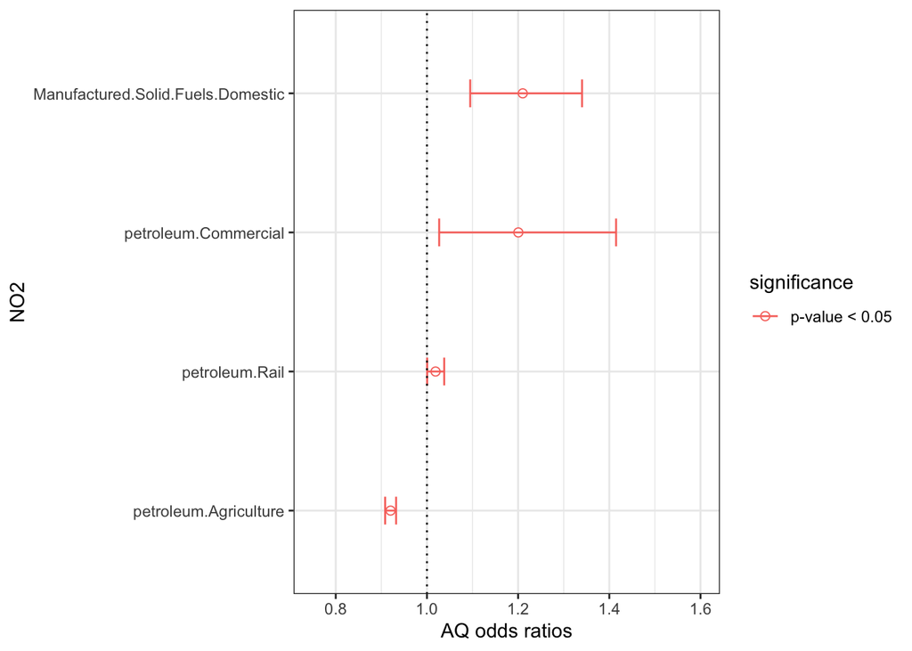

```r
# Calculate odds ratio (OR) for plotting
# Format OR
NO2_rd_odds = data.frame(cbind(exp(cbind(OR = coef(model_NO2_gamma.final.v2), confint(model_NO2_gamma.final.v2))), p_value = summary(model_NO2_gamma.final.v2)$coefficients[,4]))
NO2_rsd_odds = data.frame(cbind(exp(cbind(OR = coef(model_NO2_gamma.final.rsd), confint(model_NO2_gamma.final.rsd))), p_value = summary(model_NO2_gamma.final.rsd)$coefficients[,4]))
NO2_gas_odds = data.frame(cbind(exp(cbind(OR = coef(model_NO2_gamma.gas.v2), confint(model_NO2_gamma.gas.v2))), p_value = summary(model_NO2_gamma.gas.v2)$coefficients[,4]))
#now delete the rows that you dont want  - Intercepts
NO2_rd_odds_clean = NO2_rd_odds[-c(1,2),]
NO2_gas_odds_clean = NO2_gas_odds[-c(1,2),]
NO2_rsd_odds_clean = NO2_rsd_odds[-c(1,2),]

#make a df just with the pollutants
NO2_ff_onlyPoll = data.frame(rbind(NO2_rd_odds_clean, NO2_gas_odds_clean, NO2_rsd_odds_clean))

# Sort data
NO2_ff_onlyPoll$names = row.names(NO2_ff_onlyPoll)
NO2_ff_onlyPoll$significance = "p-value > 0.05"
NO2_ff_onlyPoll$significance[NO2_ff_onlyPoll$p_value < 0.05] <- "p-value < 0.05"

#subset
NO2_ff_onlyPoll <- subset(NO2_ff_onlyPoll, OR >= 1.01 | OR <= 0.99)
# plot
ggplot(NO2_ff_onlyPoll, aes(x=reorder(names, OR), y=OR, color= significance)) +
    geom_point(fill="white", shape=21, size = 2) +
    geom_errorbar(aes(ymin=X2.5.., ymax=X97.5..),
                  width=.2,                    # Width of the error bars
                  position=position_dodge(.9)) +
  theme_bw() +
  geom_hline(yintercept = 1, linetype="dotted") +
  coord_flip()+ylab("AQ odds ratios") +
  xlab("NO2")+
  ylim(0.75, 1.6)
```

```r
ggsave("fig_out_v4/NO2_sources.pdf")
```

#### Supplementary Table 11. Effect of fossil fuel consumption sources on annual mean nitrogen oxides AQ levels at local authority level

```r
stargazer(model_NOx_gamma_final, model_NOx_gamma.final.rsd3, model_NOx_gamma.gas.v2, type="html",ci=TRUE, ci.level=0.95, single.row=TRUE, out = "fig_out_v4/Table_ff_NOx.html")
```

|  | *Dependent variable:* |  |  |
| --- | --- | --- | --- |
|  | nox_val |  |  |
|  | (1) | (2) | (3) |
| X.people.per.sq.km | 0.0001*** (0.0001, 0.0002) | 0.0001*** (0.0001, 0.0001) | 0.0001*** (0.0001, 0.0002) |
| personal.motorcycles.Motorways | 0.001*** (0.001, 0.002) |  |  |
| personal.buses.A.roads | 0.0001*** (0.00005, 0.0002) |  |  |
| personal.motorcycles.A.roads | -0.001*** (-0.001, -0.0004) |  |  |
| petroleum.Agriculture |  | -0.090*** (-0.106, -0.074) |  |
| Manufactured.Solid.Fuels.Domestic |  | 0.236*** (0.126, 0.346) |  |
| petroleum.Commercial |  | 0.270*** (0.088, 0.452) |  |
| Domestic.mean.gas.consumption |  |  | 0.00004** (0.00000, 0.0001) |
| Constant | 2.571*** (2.496, 2.646) | 2.658*** (2.586, 2.731) | 2.138*** (1.708, 2.567) |
| Observations | 300 | 300 | 300 |
| Log Likelihood | -982.874 | -941.562 | -999.629 |
| Akaike Inf. Crit. | 1,975.747 | 1,893.123 | 2,005.257 |
| *Note:* | p<0.1; p<0.05; p<0.01 |  |  |

OR graphs with individual variables:

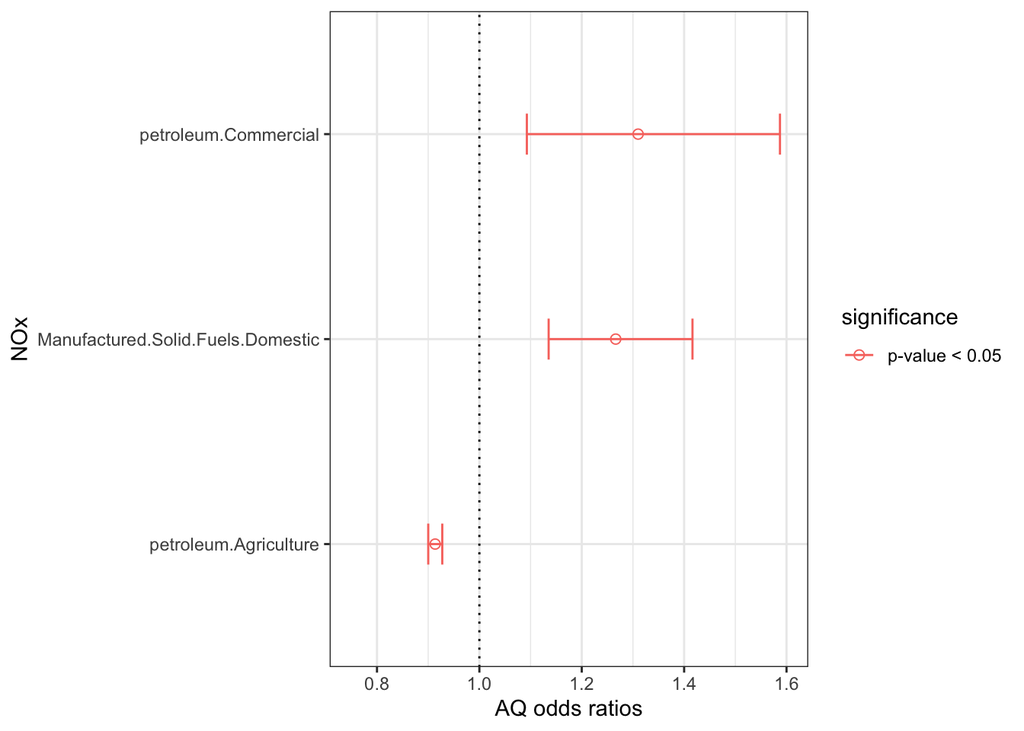

```r
# Calculate odds ratio (OR) for plotting
# Format OR
NOx_rd_odds = data.frame(cbind(exp(cbind(OR = coef(model_NOx_gamma_final), confint(model_NOx_gamma_final))), p_value = summary(model_NOx_gamma_final)$coefficients[,4]))
NOx_rsd_odds = data.frame(cbind(exp(cbind(OR = coef(model_NOx_gamma.final.rsd3), confint(model_NOx_gamma.final.rsd3))), p_value = summary(model_NOx_gamma.final.rsd3)$coefficients[,4]))
NOx_gas_odds = data.frame(cbind(exp(cbind(OR = coef(model_NOx_gamma.gas.v2), confint(model_NOx_gamma.gas.v2))), p_value = summary(model_NOx_gamma.gas.v2)$coefficients[,4]))

#now delete the rows that you dont want - Intercepts
NOx_rd_odds_clean = NOx_rd_odds[-c(1,2),]
NOx_gas_odds_clean = NOx_gas_odds[-c(1,2),]
NOx_rsd_odds_clean = NOx_rsd_odds[-c(1,2),]

#make a df just with the pollutants
NOx_ff_onlyPoll = data.frame(rbind(NOx_rd_odds_clean, NOx_gas_odds_clean, NOx_rsd_odds_clean))

# Sort data
NOx_ff_onlyPoll$names = row.names(NOx_ff_onlyPoll)
NOx_ff_onlyPoll$significance = "p-value > 0.05"
NOx_ff_onlyPoll$significance[NOx_ff_onlyPoll$p_value < 0.05] <- "p-value < 0.05"

#subset
NOx_ff_onlyPoll <- subset(NOx_ff_onlyPoll, OR >= 1.01 | OR < 0.99)

# plot
ggplot(NOx_ff_onlyPoll, aes(x=reorder(names, OR), y=OR, color= significance)) +
    geom_point(fill="white", shape=21, size = 2) +
    geom_errorbar(aes(ymin=X2.5.., ymax=X97.5..),
                  width=.2,                    # Width of the error bars
                  position=position_dodge(.9)) +
  theme_bw() +
  geom_hline(yintercept = 1, linetype="dotted") +
  coord_flip()+ylab("AQ odds ratios") +
  xlab("NOx")+
  ylim(0.75, 1.6)
```

```r
ggsave("fig_out_v4/NOx_sources.pdf")
```

#### Supplementary Table 12. Effect of fossil fuel consumption sources on annual mean ozone AQ levels at local authority level

```r
stargazer(model_O3_gamma_final, model_O3_gamma_final.rsd, model_O3_gamma.gas.v2, type="html",ci=TRUE, ci.level=0.95, single.row=TRUE, out = "fig_out_v4/Table_ff_O3.html")
```

|  | *Dependent variable:* |  |  |
| --- | --- | --- | --- |
|  | o3_val |  |  |
|  | (1) | (2) | (3) |
| personal.buses.A.roads | -0.002*** (-0.003, -0.002) |  |  |
| personal.motorcycles.A.roads | 0.009*** (0.006, 0.011) |  |  |
| personal.motorcycles.Minor.roads | 0.008*** (0.005, 0.011) |  |  |
| freight.HGV.Motorways | -0.0001*** (-0.0002, -0.0001) |  |  |
| personal.motorcycles.Motorways | 0.018*** (0.012, 0.024) |  |  |
| X.people.per.sq.km |  | -0.0003*** (-0.0005, -0.0002) | -0.0003*** (-0.0005, -0.0002) |
| petroleum.Commercial |  | 2.140*** (0.708, 3.573) |  |
| petroleum.Rail |  | -0.284*** (-0.476, -0.092) |  |
| Non.domestic.mean.gas.consumption |  |  | -0.00000*** (-0.00000, -0.00000) |
| Constant | 7.205*** (6.614, 7.796) | 8.285*** (7.658, 8.911) | 9.352*** (8.678, 10.026) |
| Observations | 300 | 300 | 300 |
| Log Likelihood | -720.046 | -783.971 | -781.426 |
| Akaike Inf. Crit. | 1,452.092 | 1,575.942 | 1,568.852 |
| *Note:* | p<0.1; p<0.05; p<0.01 |  |  |

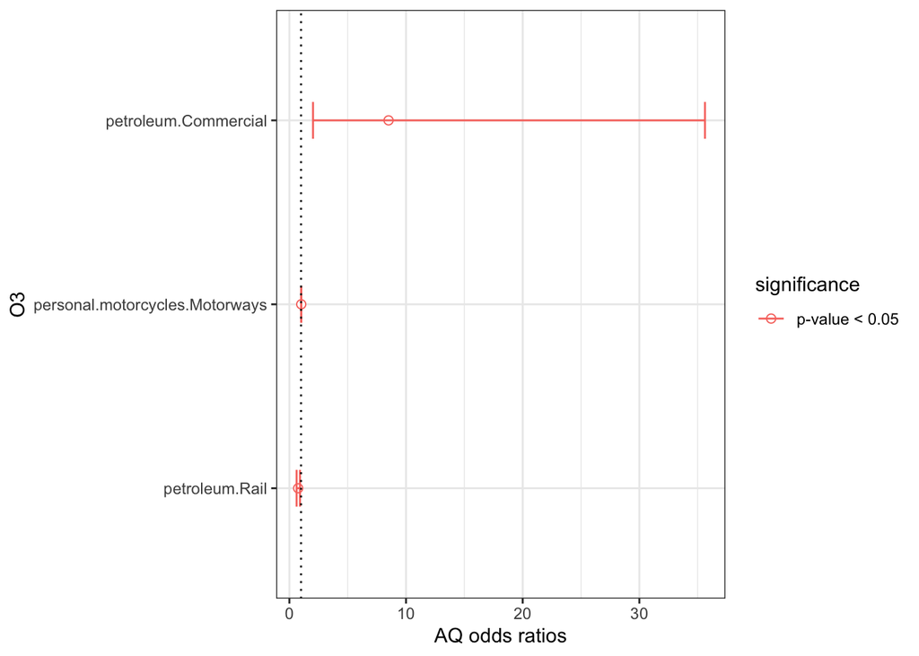

```r
# Calculate odds ratio (OR) for plotting
# Format OR
O3_rd_odds = data.frame(cbind(exp(cbind(OR = coef(model_O3_gamma_final), confint(model_O3_gamma_final))), p_value = summary(model_O3_gamma_final)$coefficients[,4]))
O3_rsd_odds = data.frame(cbind(exp(cbind(OR = coef(model_O3_gamma_final.rsd), confint(model_O3_gamma_final.rsd))), p_value = summary(model_O3_gamma_final.rsd)$coefficients[,4]))
O3_gas_odds = data.frame(cbind(exp(cbind(OR = coef(model_O3_gamma.gas.v2), confint(model_O3_gamma.gas.v2))), p_value = summary(model_O3_gamma.gas.v2)$coefficients[,4]))

#now delete the rows that you dont want - Intercepts
O3_rd_odds_clean = O3_rd_odds[-c(1,2),]
O3_gas_odds_clean = O3_gas_odds[-c(1,2),]
O3_rsd_odds_clean = O3_rsd_odds[-c(1,2),]

#make a df just with the pollutants
O3_ff_onlyPoll = data.frame(rbind(O3_rd_odds_clean, O3_gas_odds_clean, O3_rsd_odds_clean))

# Sort data
O3_ff_onlyPoll$names = row.names(O3_ff_onlyPoll)
O3_ff_onlyPoll$significance = "p-value > 0.05"
O3_ff_onlyPoll$significance[O3_ff_onlyPoll$p_value < 0.05] <- "p-value < 0.05"

#subset
O3_ff_onlyPoll <- subset(O3_ff_onlyPoll, OR >= 1.01 | OR <= 0.99)
# plot
ggplot(O3_ff_onlyPoll, aes(x=reorder(names, OR), y=OR, color= significance)) +
    geom_point(fill="white", shape=21, size = 2) +
    geom_errorbar(aes(ymin=X2.5.., ymax=X97.5..),
                  width=.2,                    # Width of the error bars
                  position=position_dodge(.9)) +
  theme_bw() +
  geom_hline(yintercept = 1, linetype="dotted") +
  coord_flip()+ylab("AQ odds ratios") +
  xlab("O3")
```

```r
ggsave("fig_out_v4/O3_sources.pdf")
```

#### Supplementary Table 13. Effect of fossil fuel consumption sources on annual mean SO2 AQ levels at local authority level

```r
library(stargazer)
stargazer(model_SO2_gamma_final, model_SO2_gamma.final.rsd, model_SO2_gamma.gas.v2, type ="html", ci=TRUE, ci.level=0.95, single.row=TRUE, out = "fig_out_v4/Table_ff_SO2.html")
```

|  | *Dependent variable:* |  |  |
| --- | --- | --- | --- |
|  | so2_val |  |  |
|  | (1) | (2) | (3) |
| petroleum.Agriculture |  | -0.077*** (-0.090, -0.064) |  |
| Manufactured.Solid.Fuels.Domestic |  | 0.301*** (0.195, 0.406) |  |
| X.people.per.sq.km | 0.0001*** (0.0001, 0.0001) | 0.00005*** (0.00003, 0.0001) | 0.0001*** (0.0001, 0.0001) |
| personal.motorcycles.A.roads | -0.001*** (-0.001, -0.001) |  |  |
| personal.buses.A.roads | 0.0001*** (0.0001, 0.0002) |  |  |
| freight.HGV.Motorways | 0.00000*** (0.00000, 0.00001) |  |  |
| petroleum.Rail |  | 0.030*** (0.010, 0.050) |  |
| petroleum.Industrial |  | 0.001** (0.0001, 0.001) |  |
| petroleum.Public.Administration |  | -0.149** (-0.281, -0.018) |  |
| Non.domestic.mean.gas.consumption |  |  | 0.00000*** (0.00000, 0.00000) |
| Constant | 0.217*** (0.152, 0.281) | 0.168*** (0.101, 0.235) | 0.130*** (0.053, 0.208) |
| Observations | 300 | 300 | 300 |
| Log Likelihood | -180.654 | -144.982 | -206.674 |
| Akaike Inf. Crit. | 371.308 | 303.964 | 419.348 |
| *Note:* | p<0.1; p<0.05; p<0.01 |  |  |

*: p<0.1; **: p<0.05; ***: p<0.01  
Summary of reported contributions of fossil fuel consumption sources on annual mean SO2 concentration. Each column represents an individual single-pollutant generalized linear model (gamma) used to assess the effects of road transport fuels (1), residual fuels (2) and gas consumption (3) on annual average concentration of SO2. The p-values are indicated using the number of asterisks beside the estimates. glm, generalized linear model; so2_val, annual mean sulphur dioxide values; Akaike Inf. Crit., Akaike’s Information Criteria.

### Calculate the odds ratios

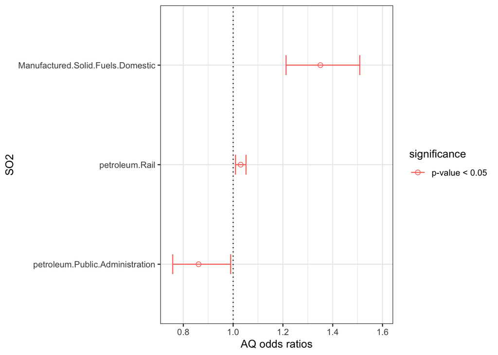

```r
# Format OR
SO2_rd_odds = data.frame(cbind(exp(cbind(OR = coef(model_SO2_gamma_final), confint(model_SO2_gamma_final))), p_value = summary(model_SO2_gamma_final)$coefficients[,4]))
SO2_rsd_odds = data.frame(cbind(exp(cbind(OR = coef(model_SO2_gamma.final.rsd), confint(model_SO2_gamma.final.rsd))), p_value = summary(model_SO2_gamma.final.rsd)$coefficients[,4]))
SO2_gas_odds = data.frame(cbind(exp(cbind(OR = coef(model_SO2_gamma.gas.v2), confint(model_SO2_gamma.gas.v2))), p_value = summary(model_SO2_gamma.gas.v2)$coefficients[,4]))
#now delete the rows that you dont want  - Intercepts
SO2_rd_odds_clean = SO2_rd_odds[-c(1,2),]
SO2_gas_odds_clean = SO2_gas_odds[-c(1,2),]
SO2_rsd_odds_clean = SO2_rsd_odds[-c(1,2),]

#make a df just with the pollutants
SO2_ff_onlyPoll = data.frame(rbind(SO2_rd_odds_clean, SO2_gas_odds_clean, SO2_rsd_odds_clean))

# Sort data
SO2_ff_onlyPoll$names = row.names(SO2_ff_onlyPoll)
SO2_ff_onlyPoll$significance = "p-value > 0.05"
SO2_ff_onlyPoll$significance[NO2_ff_onlyPoll$p_value < 0.05] <- "p-value < 0.05"

#take out incorrect variables
SO2_ff_onlyPoll <- subset(SO2_ff_onlyPoll, OR >= 1.01 | OR <= 0.99)

# plot
ggplot(SO2_ff_onlyPoll, aes(x=reorder(names, OR), y=OR, color= significance)) +
    geom_point(fill="white", shape=21, size = 2) +
    geom_errorbar(aes(ymin=X2.5.., ymax=X97.5..),
                  width=.2,                    # Width of the error bars
                  position=position_dodge(.9)) +
  theme_bw() +
  geom_hline(yintercept = 1, linetype="dotted") +
  coord_flip()+ylab("AQ odds ratios") +
  xlab("SO2") +
  ylim(0.75, 1.6)
```

```r
ggsave("fig_out_v4/SO2_sources.pdf")
```